# IntroToNeuralNetworks - IntroToTensorflow - 1

One should look for what is and not what he thinks should be. (Albert Einstein)

# Intro to TensorFlow: Topic introduction

# Module completion checklist

| Objective | Complete |
| --- | --- |
| Introduce TensorFlow and Keras |  |
| Define a neural network model using Tensorflow |  |

# Warm up: What is TensorFlow

- Have you heard of TensorFlow, an open source platform for machine learning?
- Watch the video [TensorFlow in 100 seconds](https://youtu.be/i8NETqtGHms) to get started and know more about TensorFlow
- After watching the video, share your thoughts on the following questions in the chat:
  - What feature was the most interesting?
  - What application was the most surprising?

[figure not shown]

# TensorFlow

- TensorFlow is a base production-grade, **deep learning framework** for distributed processing and data flow graphs modeled on tensor data objects (originally from Google)
- Its core is in C++ with a layer of Python around it, abstracting processes into graphs and giving the core instructions
- [Click here](https://www.tensorflow.org/api_docs/python/) to get more information about TensorFlow

[figure not shown]

# Keras

- Keras is a more high-level wrapper around TensorFlow, making it easier to build models that resemble other Python & scikit-learn functions you are used to
- It is a **deep learning library** explicitly built for Python
- It’s a few layers up the abstraction chain from the core in C++, but it allows us to train models efficiently
- [Click here](https://www.tensorflow.org/api_docs/python/tf/keras) to get more information about Keras
- Note: Since TensorFlow 2.0 fully integrated Keras, there is no need to install Keras separately

[figure not shown]

# TensorFlow and Keras

- TensorFlow and Keras do **NOT** have to go together!
- Keras can be run on top of other systems like CNTK
- You can place your TensorFlow code directly into the Keras training pipeline or model
- If you want to develop your own algorithms, you can do so with TensorFlow

[figure not shown]

# TensorFlow vs. Keras

- Although TensorFlow native modules alone can do everything (and then some) that Keras modules are built for, there are a few advantages of using Keras based on the four guiding principles used by Francois Chollet (the author of Keras):
  - **Modularity**: a model can be understood as a sequence or a graph alone; all the concerns of a deep learning model are discrete components that can be combined in arbitrary ways
  - **Minimalism**: the library provides just enough to achieve an outcome, no frills, and maximizing readability
  - **Extensibility**: new components are easy to add and use within the framework, intended for researchers to try and explore new ideas
  - **Python**: no separate model files with custom file formats as everything is native Python

# TensorFlow’s APIs

- TensorFlow has APIs that support several languages including:
  - Python
  - JavaScript
  - C++
  - Java
- Additional community-supported languages include C#, Julia, Ruby, Rust, and Scala
- There are several available modules such as Lite and TensorFlow Extended (TFX)
- [Click here](https://www.tensorflow.org/api_docs) to get more information about TensorFlow’s APIs

# Tensors

What are tensors?

- Tensors are multi-dimensional arrays with a uniform type (called a dtype)
- All tensors are immutable like Python numbers and strings: you can never update the contents of a tensor, only create a new one
- When working with TensorFlow, there is a high probability that you will end up working with tensors at some point

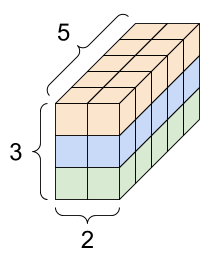

# Tensor vocabulary

- Let’s discuss important concepts associated to tensors:
  - **Shape**: The length (number of elements) of each of the dimensions of a tensor
  - **Rank**: Number of tensor dimensions
  - **Axis or Dimension**: A particular dimension of a tensor
  - **Size**: The total number of items in the tensor, the product shape vector

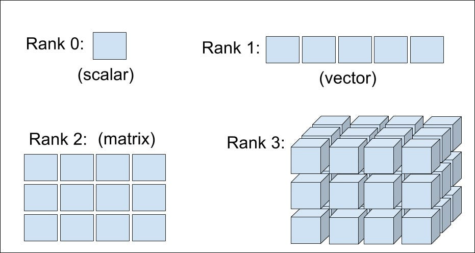

# Tensor shape

- You may be familiar with scalars, vectors, matrices, and tensors, but let’s discuss how these translate into TensorFlow

[output not shown]

- [Click here](https://www.tensorflow.org/guide/tensor) to get more information on creating basic tensors

# Load TensorFlow for Python

- Loading TF is very simple, just run the following code:

```python
# Import tensorflow.
import tensorflow as tf
```

- The `tf` library is the main TensorFlow package that is loaded into the environment
- [Click here](https://www.tensorflow.org/api_docs/python/tf) to get the list of all modules available through `tf`

# Module completion checklist

| Objective | Complete |
| --- | --- |
| Introduce TensorFlow and Keras | **✔** |
| Define a neural network model using Tensorflow |  |

# Neural network model: layers

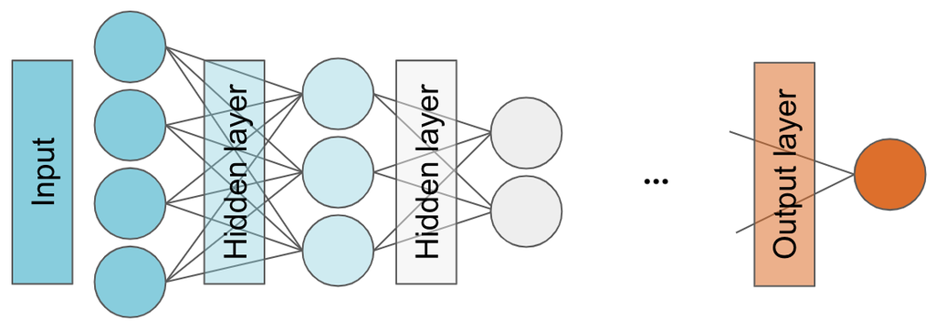

- Any neural network modeling starts with the architecture
- We need 1 input and 1 output layer with at least 1 **hidden** layer in between
- The number of **hidden layers** determines the **depth of the network**
- It’s a trial-and-error process; you must adjust it for every model you build

# Neural network model: layers and neurons

- The output for a binary classification problem will have a single neuron with a sigmoid activation function

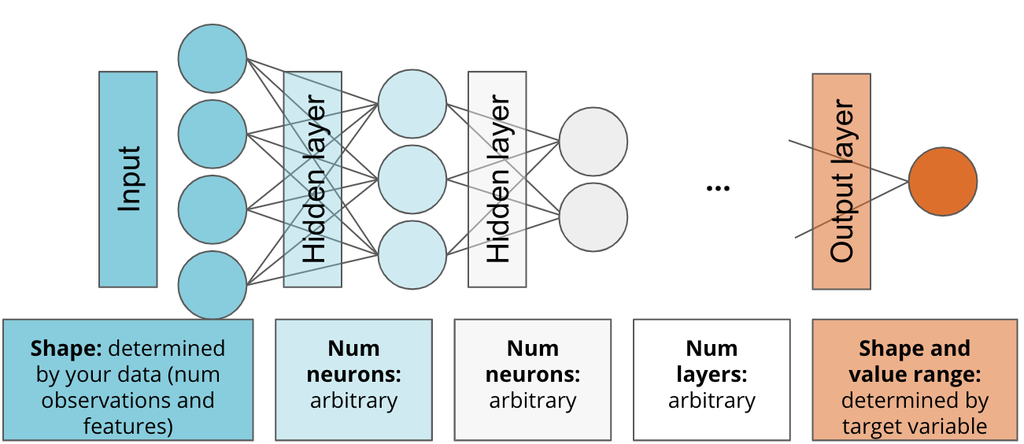

# Neural network model: implemented in tf.keras

- Keras model architecture follows this logic:
  - choose model type
  - add your layers one-by-one and make sure to pick your parameters properly

# Neural network model: implemented in tf.keras (cont’d)

- There are two main types of models available in Keras:
  - **Sequential model:** A linear stack of layers with each layer having exactly one input and one output tensor
  - **Functional API:** Uses the same layers as the sequential model but provides more flexibility and can handle models with non-linear topology, shared layers, and multiple inputs or outputs

# Neural network model: implemented in tf.keras (cont’d)

- We will discuss the `Sequential` model first, as we will start by working with one input tensor and one output tensor at each layer
  - Each layer will be `Dense`, i.e., densely connected to the preceding and following layers
  - For each layer we just need to pick appropriate parameters